title: "Case Study: Stock Portfolio Allocation, Part 2" subtitle: PSTAT 234 (Fall 2025) format: clean-revealjs: bibliographystyle: "chicago-author-date" fig-width: 30 code-copy: hover code-line-numbers: true author:

- name: Sang-Yun Oh affiliations: "University of California, Santa Barbara" date: "February 27, 2025" date-format: long bibliography: [../static/references.bib] execute: echo: true code-fold: true editor: render-on-save: true

```python
#| echo: false

import pandas as pd
import numpy as np
import seaborn as sns
sns.set_theme(style="whitegrid")

import cvxpy as cvx
import matplotlib.pyplot as plt
```

# Portfolio Allocation: Dow Jones component stocks

Stock data can have irregularities such as missing data due stocks being added and removed from the index. Some examples are

- Alcoa Corp. (AA) was removed in 2013
- Apple (AAPL) was added in 2015
- E.I. du Pont de Nemours & Company (DD) was removed and replaced with Dow du Pont (DWDP) as a continuation in 2017

## Stock Symbols

For simplicity the stocks we will use are based on the most recent DJIA constituent companies

```python
#| echo: false
dowjones_components = [
    'AAPL','AXP','BA','BAC','CAT',
    'CSCO','CVX','DD','DIS','GE',
    'HD','HPQ','IBM','INTC','JNJ',
    'JPM','KO','MCD','MMM',
    'MRK','MSFT','PFE','PG','T',
    'TRV','VZ','WMT','XOM'
]

symbols = pd.read_csv('data/tickers.csv').set_index('code')
symbols['name'] # full company names
```

```
code
AAPL                              Apple Inc (AAPL)
AXP                     American Express Co. (AXP)
BA                             The Boeing Co. (BA)
BAC                    Bank of America Corp. (BAC)
CAT                         Caterpillar Inc. (CAT)
CSCO                     Cisco Systems Inc. (CSCO)
CVX                      Chevron Corporation (CVX)
DD            E.I. du Pont de Nemours and Co. (DD)
DIS                  Disney (Walt) Co. (The) (DIS)
GE                        General Electric Co (GE)
HD                             Home Depot Inc (HD)
HPQ                       Hewlett-Packard Co (HPQ)
IBM     International Business Machines Corp (IBM)
INTC                             Intel Corp (INTC)
JNJ                        Johnson & Johnson (JNJ)
JPM                          JP Morgan Chase (JPM)
KO                         Coca-Cola Co (The) (KO)
MCD                          McDonald's Corp (MCD)
MMM                                    3M Co (MMM)
MRK                          Merck & Co. Inc (MRK)
MSFT                  Microsoft Corporation (MSFT)
PFE                               Pfizer Inc (PFE)
PG                       Procter & Gamble Co. (PG)
T                                     AT&T Inc (T)
TRV            Travelers Companies Inc (The) (TRV)
UTX                United Technologies Corp. (UTX)
VZ                 Verizon Communications Inc (VZ)
WMT                          Wal-Mart Stores (WMT)
XOM                        Exxon Mobil Corp. (XOM)
Name: name, dtype: object
```

## Load/Import Data from Yahoo Finance

```python
#| code-fold: true
import yfinance as yf

store = pd.HDFStore('data/yfinance-data-store.h5')

if 'rawdata' in store:
    rawdata = store['rawdata']
    print('Data loaded from store')
else:
    print('Downloading data from Yahoo Finance')
    print('set auto_adjust=False to get adjusted closing price as separate column')
    rawdata = yf.download(dowjones_components, start="2000-01-01", end="2025-11-01", auto_adjust=True)
    store['rawdata'] = rawdata
```

```
Data loaded from store
```

### Preview Data

```python
rawdata.head()
```

| Price Ticker Date | Close AAPL | Close AXP | Close BA | Close BAC | Close CAT | Close CSCO | Close CVX | Close DD | Close DIS | Close GE | ... | Volume MMM | Volume MRK | Volume MSFT | Volume PFE | Volume PG | Volume T | Volume TRV | Volume VZ | Volume WMT | Volume XOM |
| --- | --- | --- | --- | --- | --- | --- | --- | --- | --- | --- | --- | --- | --- | --- | --- | --- | --- | --- | --- | --- | --- |
| 2000-01-03 | 0.839280 | 32.323586 | 25.940268 | 12.490799 | 12.574042 | 35.148087 | 15.875281 | 11.853917 | 22.736227 | 129.774673 | ... | 2599386 | 6265782 | 53228400 | 12873345 | 4275000 | 7668476 | 336400 | 4663843 | 25109700 | 13458200 |
| 2000-01-04 | 0.768521 | 31.103098 | 25.899942 | 11.749414 | 12.412425 | 33.176201 | 15.875281 | 11.529919 | 24.068050 | 124.583733 | ... | 3245705 | 7894689 | 54119000 | 14208974 | 4270800 | 9497846 | 494400 | 5005878 | 20235300 | 14510800 |
| 2000-01-05 | 0.779767 | 30.313122 | 27.513647 | 11.878352 | 12.703340 | 33.074562 | 16.160040 | 11.904197 | 25.066923 | 124.367424 | ... | 4424482 | 7963018 | 64059600 | 12981591 | 5098400 | 12035160 | 736000 | 6368681 | 21056100 | 17485000 |
| 2000-01-06 | 0.712287 | 30.930702 | 27.796047 | 12.893729 | 13.349821 | 32.525688 | 16.848200 | 12.239370 | 24.068050 | 126.030174 | ... | 7147057 | 4989004 | 54976600 | 11115273 | 6524200 | 9471366 | 660400 | 4705763 | 19633500 | 19461600 |
| 2000-01-07 | 0.746027 | 31.381020 | 28.602884 | 12.555267 | 13.786201 | 34.436577 | 17.144821 | 12.513094 | 23.687531 | 130.910217 | ... | 4905035 | 10871218 | 62013600 | 17962163 | 9832000 | 7792534 | 594700 | 5043907 | 23930700 | 16603800 |

5 rows × 140 columns

```python
rawdata.tail()
```

| Price Ticker Date | Close AAPL | Close AXP | Close BA | Close BAC | Close CAT | Close CSCO | Close CVX | Close DD | Close DIS | Close GE | ... | Volume MMM | Volume MRK | Volume MSFT | Volume PFE | Volume PG | Volume T | Volume TRV | Volume VZ | Volume WMT | Volume XOM |
| --- | --- | --- | --- | --- | --- | --- | --- | --- | --- | --- | --- | --- | --- | --- | --- | --- | --- | --- | --- | --- | --- |
| 2025-10-27 | 268.549652 | 361.670013 | 223.000000 | 53.020000 | 527.070007 | 71.389999 | 153.564911 | 34.050209 | 112.339996 | 312.839996 | ... | 2922300 | 7226600 | 18734700 | 34974900 | 7775300 | 86220400 | 1108100 | 27487200 | 16375900 | 10975400 |
| 2025-10-28 | 268.739471 | 361.029999 | 223.330002 | 52.869999 | 524.469971 | 72.620003 | 152.427628 | 34.267780 | 111.650002 | 309.790009 | ... | 2448100 | 8345900 | 29986700 | 50152400 | 5819300 | 77662500 | 1341300 | 30719200 | 13323000 | 9535200 |
| 2025-10-29 | 269.438812 | 358.220001 | 213.580002 | 52.580002 | 585.489990 | 71.330002 | 153.386917 | 34.376568 | 110.239998 | 314.279999 | ... | 3163400 | 10921900 | 36023000 | 65438400 | 7405500 | 102715000 | 1262700 | 53730200 | 11986400 | 12570600 |
| 2025-10-30 | 271.137146 | 358.880005 | 200.080002 | 53.029999 | 583.150024 | 72.910004 | 151.824356 | 34.087868 | 111.839996 | 310.750000 | ... | 2143700 | 16678800 | 41023100 | 157478000 | 6760700 | 82167800 | 1473500 | 47371000 | 14065100 | 16172900 |
| 2025-10-31 | 270.108154 | 360.730011 | 201.020004 | 53.450001 | 577.260010 | 73.110001 | 155.977966 | 34.163181 | 112.620003 | 308.950012 | ... | 2096600 | 12385000 | 34006400 | 132697400 | 7930300 | 89936800 | 1900900 | 52181800 | 20237000 | 20213400 |

5 rows × 140 columns

### Hierarchical Indexing

- Column indexing is hierarchical
- Close, high, low, open, and volume are given for each stock symbol

```python
## Hierarchical Index
rawdata.columns
```

```
MultiIndex([( 'Close', 'AAPL'),
            ( 'Close',  'AXP'),
            ( 'Close',   'BA'),
            ( 'Close',  'BAC'),
            ( 'Close',  'CAT'),
            ( 'Close', 'CSCO'),
            ( 'Close',  'CVX'),
            ( 'Close',   'DD'),
            ( 'Close',  'DIS'),
            ( 'Close',   'GE'),
            ...
            ('Volume',  'MMM'),
            ('Volume',  'MRK'),
            ('Volume', 'MSFT'),
            ('Volume',  'PFE'),
            ('Volume',   'PG'),
            ('Volume',    'T'),
            ('Volume',  'TRV'),
            ('Volume',   'VZ'),
            ('Volume',  'WMT'),
            ('Volume',  'XOM')],
           names=['Price', 'Ticker'], length=140)
```

- Column levels can be named:

```python
rawdata.columns = rawdata.columns.set_names(['Value', 'Symbol'])
rawdata.head()
```

| Value Symbol Date | Close AAPL | Close AXP | Close BA | Close BAC | Close CAT | Close CSCO | Close CVX | Close DD | Close DIS | Close GE | ... | Volume MMM | Volume MRK | Volume MSFT | Volume PFE | Volume PG | Volume T | Volume TRV | Volume VZ | Volume WMT | Volume XOM |
| --- | --- | --- | --- | --- | --- | --- | --- | --- | --- | --- | --- | --- | --- | --- | --- | --- | --- | --- | --- | --- | --- |
| 2000-01-03 | 0.839280 | 32.323586 | 25.940268 | 12.490799 | 12.574042 | 35.148087 | 15.875281 | 11.853917 | 22.736227 | 129.774673 | ... | 2599386 | 6265782 | 53228400 | 12873345 | 4275000 | 7668476 | 336400 | 4663843 | 25109700 | 13458200 |
| 2000-01-04 | 0.768521 | 31.103098 | 25.899942 | 11.749414 | 12.412425 | 33.176201 | 15.875281 | 11.529919 | 24.068050 | 124.583733 | ... | 3245705 | 7894689 | 54119000 | 14208974 | 4270800 | 9497846 | 494400 | 5005878 | 20235300 | 14510800 |
| 2000-01-05 | 0.779767 | 30.313122 | 27.513647 | 11.878352 | 12.703340 | 33.074562 | 16.160040 | 11.904197 | 25.066923 | 124.367424 | ... | 4424482 | 7963018 | 64059600 | 12981591 | 5098400 | 12035160 | 736000 | 6368681 | 21056100 | 17485000 |
| 2000-01-06 | 0.712287 | 30.930702 | 27.796047 | 12.893729 | 13.349821 | 32.525688 | 16.848200 | 12.239370 | 24.068050 | 126.030174 | ... | 7147057 | 4989004 | 54976600 | 11115273 | 6524200 | 9471366 | 660400 | 4705763 | 19633500 | 19461600 |
| 2000-01-07 | 0.746027 | 31.381020 | 28.602884 | 12.555267 | 13.786201 | 34.436577 | 17.144821 | 12.513094 | 23.687531 | 130.910217 | ... | 4905035 | 10871218 | 62013600 | 17962163 | 9832000 | 7792534 | 594700 | 5043907 | 23930700 | 16603800 |

5 rows × 140 columns

```python
rawdata.columns
```

```
MultiIndex([( 'Close', 'AAPL'),
            ( 'Close',  'AXP'),
            ( 'Close',   'BA'),
            ( 'Close',  'BAC'),
            ( 'Close',  'CAT'),
            ( 'Close', 'CSCO'),
            ( 'Close',  'CVX'),
            ( 'Close',   'DD'),
            ( 'Close',  'DIS'),
            ( 'Close',   'GE'),
            ...
            ('Volume',  'MMM'),
            ('Volume',  'MRK'),
            ('Volume', 'MSFT'),
            ('Volume',  'PFE'),
            ('Volume',   'PG'),
            ('Volume',    'T'),
            ('Volume',  'TRV'),
            ('Volume',   'VZ'),
            ('Volume',  'WMT'),
            ('Volume',  'XOM')],
           names=['Value', 'Symbol'], length=140)
```

```python
rawdata.columns.levels
```

```
FrozenList([['Close', 'High', 'Low', 'Open', 'Volume'], ['AAPL', 'AXP', 'BA', 'BAC', 'CAT', 'CSCO', 'CVX', 'DD', 'DIS', 'GE', 'HD', 'HPQ', 'IBM', 'INTC', 'JNJ', 'JPM', 'KO', 'MCD', 'MMM', 'MRK', 'MSFT', 'PFE', 'PG', 'T', 'TRV', 'VZ', 'WMT', 'XOM']])
```

#### Subset First Level 1

- Subsetting first level of hierarchical indexing: `Close`

```python
rawdata['Close'].head()
```

| Symbol Date | AAPL | AXP | BA | BAC | CAT | CSCO | CVX | DD | DIS | GE | ... | MMM | MRK | MSFT | PFE | PG | T | TRV | VZ | WMT | XOM |
| --- | --- | --- | --- | --- | --- | --- | --- | --- | --- | --- | --- | --- | --- | --- | --- | --- | --- | --- | --- | --- | --- |
| 2000-01-03 | 0.839280 | 32.323586 | 25.940268 | 12.490799 | 12.574042 | 35.148087 | 15.875281 | 11.853917 | 22.736227 | 129.774673 | ... | 19.343803 | 25.427525 | 35.668091 | 11.650893 | 27.024214 | 6.324178 | 17.456139 | 15.576514 | 14.239633 | 17.255524 |
| 2000-01-04 | 0.768521 | 31.103098 | 25.899942 | 11.749414 | 12.412425 | 33.176201 | 15.875281 | 11.529919 | 24.068050 | 124.583733 | ... | 18.575180 | 24.534512 | 34.463211 | 11.216841 | 26.504219 | 5.954147 | 17.224714 | 15.072998 | 13.706803 | 16.925014 |
| 2000-01-05 | 0.779767 | 30.313122 | 27.513647 | 11.878352 | 12.703340 | 33.074562 | 16.160040 | 11.904197 | 25.066923 | 124.367424 | ... | 19.113220 | 25.498028 | 34.826580 | 11.399590 | 25.999968 | 6.046654 | 17.092470 | 15.576514 | 13.427073 | 17.847692 |
| 2000-01-06 | 0.712287 | 30.930702 | 27.796047 | 12.893729 | 13.349821 | 32.525688 | 16.848200 | 12.239370 | 24.068050 | 126.030174 | ... | 20.650473 | 25.709532 | 33.659988 | 11.810803 | 27.197546 | 5.929497 | 17.423077 | 15.497396 | 13.573600 | 18.770374 |
| 2000-01-07 | 0.746027 | 31.381020 | 28.602884 | 12.555267 | 13.786201 | 34.436577 | 17.144821 | 12.513094 | 23.687531 | 130.910217 | ... | 21.060410 | 28.177097 | 34.099834 | 12.610372 | 29.372086 | 5.980319 | 18.117361 | 15.382957 | 14.599282 | 18.715279 |

5 rows × 28 columns

#### Subset First Level 2

```python
rawdata.loc[:, 'High':'Low'].head()
```

| Value Symbol Date | High AAPL | High AXP | High BA | High BAC | High CAT | High CSCO | High CVX | High DD | High DIS | High GE | ... | Low MMM | Low MRK | Low MSFT | Low PFE | Low PG | Low T | Low TRV | Low VZ | Low WMT | Low XOM |
| --- | --- | --- | --- | --- | --- | --- | --- | --- | --- | --- | --- | --- | --- | --- | --- | --- | --- | --- | --- | --- | --- |
| 2000-01-03 | 0.843498 | 33.813864 | 26.908489 | 12.958197 | 12.671014 | 35.859586 | 16.302419 | 12.043848 | 22.783793 | 132.964966 | ... | 19.279752 | 25.004515 | 34.271967 | 11.559513 | 26.646032 | 6.273719 | 17.257773 | 15.495303 | 13.959902 | 17.159124 |
| 2000-01-04 | 0.829439 | 32.040944 | 26.545424 | 12.361867 | 12.864961 | 34.802485 | 15.970201 | 11.753367 | 24.258312 | 128.044396 | ... | 18.575180 | 24.346507 | 34.348461 | 10.965547 | 26.157553 | 5.853229 | 17.026349 | 14.878089 | 13.680161 | 16.856158 |
| 2000-01-05 | 0.828971 | 31.522557 | 27.957416 | 11.975055 | 12.978094 | 33.989347 | 16.432933 | 11.904197 | 25.209621 | 127.179215 | ... | 18.677664 | 24.464008 | 33.468707 | 11.262521 | 25.842392 | 5.979376 | 17.059409 | 15.202938 | 13.253907 | 17.145353 |
| 2000-01-06 | 0.802260 | 31.368160 | 28.038103 | 12.893729 | 13.511441 | 33.135545 | 16.931254 | 12.647163 | 25.209619 | 127.125146 | ... | 19.330995 | 25.451026 | 33.162739 | 11.399596 | 26.488456 | 5.844790 | 16.827981 | 15.268532 | 13.360470 | 17.668665 |
| 2000-01-07 | 0.757274 | 31.599747 | 28.965967 | 12.797025 | 14.254899 | 34.477234 | 17.251606 | 12.596887 | 24.448575 | 131.396868 | ... | 20.483939 | 26.179553 | 32.837586 | 11.810801 | 27.528451 | 5.878671 | 17.621448 | 15.121398 | 13.746770 | 18.508708 |

5 rows × 56 columns

#### Subset Second Level 1

- Subsetting second level is slightly harder: `AAPL`

```python
idx = pd.IndexSlice
rawdata.loc[:, idx[:, 'AAPL']].head()
```

| Value Symbol Date | Close AAPL | High AAPL | Low AAPL | Open AAPL | Volume AAPL |
| --- | --- | --- | --- | --- | --- |
| 2000-01-03 | 0.839280 | 0.843498 | 0.762428 | 0.786328 | 535796800 |
| 2000-01-04 | 0.768521 | 0.829439 | 0.758680 | 0.811633 | 512377600 |
| 2000-01-05 | 0.779767 | 0.828971 | 0.772269 | 0.777892 | 778321600 |
| 2000-01-06 | 0.712287 | 0.802260 | 0.712287 | 0.795700 | 767972800 |
| 2000-01-07 | 0.746027 | 0.757274 | 0.716036 | 0.723534 | 460734400 |

#### Subset Second Level 2

- Subsetting `Open`, `High`, `Low`, and `Close` (OHLC) for `AAPL`:

```python
aapl = rawdata.loc[:, idx['Close':'Open', 'AAPL']]
aapl.head()
```

| Value Symbol Date | Close AAPL | High AAPL | Low AAPL | Open AAPL |
| --- | --- | --- | --- | --- |
| 2000-01-03 | 0.839280 | 0.843498 | 0.762428 | 0.786328 |
| 2000-01-04 | 0.768521 | 0.829439 | 0.758680 | 0.811633 |
| 2000-01-05 | 0.779767 | 0.828971 | 0.772269 | 0.777892 |
| 2000-01-06 | 0.712287 | 0.802260 | 0.712287 | 0.795700 |
| 2000-01-07 | 0.746027 | 0.757274 | 0.716036 | 0.723534 |

#### Subset Second Level 3

- Drop redudant index level, `AAPL`:

```python
aapl = rawdata.loc[:, idx['Close':'Open', 'AAPL']].droplevel('Symbol', axis=1).tail(60)
aapl.head()
```

| Value Date | Close | High | Low | Open |
| --- | --- | --- | --- | --- |
| 2025-08-08 | 228.868134 | 230.514661 | 218.789348 | 220.366030 |
| 2025-08-11 | 226.959976 | 229.337676 | 224.542322 | 227.699265 |
| 2025-08-12 | 229.427582 | 230.576477 | 226.850094 | 227.789171 |
| 2025-08-13 | 233.104034 | 234.772415 | 230.206834 | 230.846229 |
| 2025-08-14 | 232.554565 | 234.892296 | 230.626442 | 233.833325 |

## Candlestick Chart

```python
mmm = rawdata.loc[:, idx['Close':'Open', 'MMM']].droplevel('Symbol', axis=1).tail(60).reset_index()
```

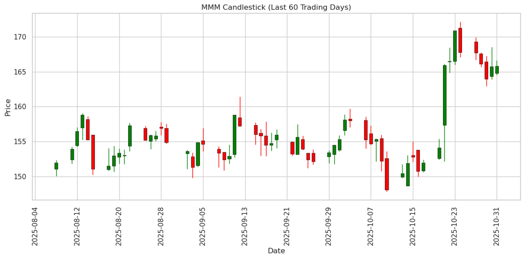

```python
fig, ax = plt.subplots(figsize=(12, 6))

# width of the candlestick body in days
body_width = 0.6  # adjust (e.g., 0.5 - 0.8) to change bar thickness

for _, r in mmm.iterrows():
  o = r['Open']; c = r['Close']; h = r['High']; l = r['Low']
  color = 'green' if c >= o else 'red'
  x = r['Date']
  ax.vlines(x, l, h, color=color, linewidth=1)
  lower = min(o, c)
  height = abs(c - o)
  ax.add_patch(
    plt.Rectangle(
      (x - pd.Timedelta(days=body_width / 2), lower),
      pd.Timedelta(days=body_width),
      height if height != 0 else 0.0001,  # ensure visible even if open == close
      facecolor=color,
      edgecolor='black',
      linewidth=0.5
    )
  )

ax.set_title('MMM Candlestick (Last 60 Trading Days)')
ax.set_ylabel('Price')
ax.set_xlabel('Date')
ax.xaxis.set_major_locator(plt.MaxNLocator(12))
plt.xticks(rotation=90)
plt.tight_layout()
plt.show()
```

## Closing prices

To get closing prices of a few stocks, following command can be used:

```python
first10 = rawdata.loc[:, idx['Close', ['MMM', 'MRK', 'PFE', 'PG', 'JNJ']]].tail(60)
first10.head()
```

| Value Symbol Date | Close MMM | Close MRK | Close PFE | Close PG | Close JNJ |
| --- | --- | --- | --- | --- | --- |
| 2025-08-08 | 151.942062 | 79.900742 | 24.154673 | 152.443970 | 172.067017 |
| 2025-08-11 | 153.934250 | 79.247192 | 24.154673 | 153.903763 | 172.553452 |
| 2025-08-12 | 156.451752 | 79.514557 | 24.223461 | 154.013000 | 171.521011 |
| 2025-08-13 | 158.780930 | 81.900978 | 24.724636 | 154.330780 | 173.149063 |
| 2025-08-14 | 155.262375 | 81.950493 | 24.675501 | 152.672379 | 173.446884 |

- Stacking transforms data into long-format:  
  *Note: unstack does the opposite*

```python
healthcare = first10.stack('Symbol', future_stack=True)
healthcare
```

| Date | Value Symbol | Close |
| --- | --- | --- |
| 2025-08-08 | MMM | 151.942062 |
|  | MRK | 79.900742 |
|  | PFE | 24.154673 |
|  | PG | 152.443970 |
|  | JNJ | 172.067017 |
| ... | ... | ... |
| 2025-10-31 | MMM | 165.787628 |
|  | MRK | 85.980003 |
|  | PFE | 24.223461 |
|  | PG | 150.369995 |
|  | JNJ | 188.869995 |

300 rows × 1 columns

### Visualization

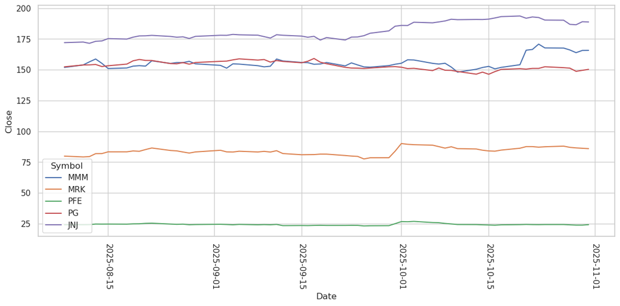

```python
plt.figure(figsize=(12, 6))
sns.lineplot(data=healthcare, x='Date', y='Close', hue='Symbol')
plt.xticks(rotation=-90)
plt.tight_layout()
plt.show()
```

## Data Cleaning

### Count missing values

- Inspect missing values:

```python
rawdata['Close'].isna().sum(axis=0)
```

```
Symbol
AAPL    0
AXP     0
BA      0
BAC     0
CAT     0
CSCO    0
CVX     0
DD      0
DIS     0
GE      0
HD      0
HPQ     0
IBM     0
INTC    0
JNJ     0
JPM     0
KO      0
MCD     0
MMM     0
MRK     0
MSFT    0
PFE     0
PG      0
T       0
TRV     0
VZ      0
WMT     0
XOM     0
dtype: int64
```

```python
anymissing = rawdata['Close'].isna().any(axis=1)
rawdata.loc[anymissing]
```

| Value | Close | Close | Close | Close | Close | Close | Close | Close | Close | Close | ... | Volume | Volume | Volume | Volume | Volume | Volume | Volume | Volume | Volume | Volume |
| --- | --- | --- | --- | --- | --- | --- | --- | --- | --- | --- | --- | --- | --- | --- | --- | --- | --- | --- | --- | --- | --- |
| Symbol | AAPL | AXP | BA | BAC | CAT | CSCO | CVX | DD | DIS | GE | ... | MMM | MRK | MSFT | PFE | PG | T | TRV | VZ | WMT | XOM |
| Date |  |  |  |  |  |  |  |  |  |  |  |  |  |  |  |  |  |  |  |  |  |

0 rows × 140 columns

## Data Cleaning

- Double check: did we remove all missing values?

```python
(rawdata.isna().sum()>0).any()
```

```
False
```

- Reset symbols to what is in `data` variable

```python
symbols = symbols.loc[rawdata.columns.levels[1].to_list()]
symbols
```

| code | name |
| --- | --- |
| AAPL | Apple Inc (AAPL) |
| AXP | American Express Co. (AXP) |
| BA | The Boeing Co. (BA) |
| BAC | Bank of America Corp. (BAC) |
| CAT | Caterpillar Inc. (CAT) |
| CSCO | Cisco Systems Inc. (CSCO) |
| CVX | Chevron Corporation (CVX) |
| DD | E.I. du Pont de Nemours and Co. (DD) |
| DIS | Disney (Walt) Co. (The) (DIS) |
| GE | General Electric Co (GE) |
| HD | Home Depot Inc (HD) |
| HPQ | Hewlett-Packard Co (HPQ) |
| IBM | International Business Machines Corp (IBM) |
| INTC | Intel Corp (INTC) |
| JNJ | Johnson & Johnson (JNJ) |
| JPM | JP Morgan Chase (JPM) |
| KO | Coca-Cola Co (The) (KO) |
| MCD | McDonald's Corp (MCD) |
| MMM | 3M Co (MMM) |
| MRK | Merck & Co. Inc (MRK) |
| MSFT | Microsoft Corporation (MSFT) |
| PFE | Pfizer Inc (PFE) |
| PG | Procter & Gamble Co. (PG) |
| T | AT&T Inc (T) |
| TRV | Travelers Companies Inc (The) (TRV) |
| VZ | Verizon Communications Inc (VZ) |
| WMT | Wal-Mart Stores (WMT) |
| XOM | Exxon Mobil Corp. (XOM) |

```python
rawdata.head()
```

| Value Symbol Date | Close AAPL | Close AXP | Close BA | Close BAC | Close CAT | Close CSCO | Close CVX | Close DD | Close DIS | Close GE | ... | Volume MMM | Volume MRK | Volume MSFT | Volume PFE | Volume PG | Volume T | Volume TRV | Volume VZ | Volume WMT | Volume XOM |
| --- | --- | --- | --- | --- | --- | --- | --- | --- | --- | --- | --- | --- | --- | --- | --- | --- | --- | --- | --- | --- | --- |
| 2000-01-03 | 0.839280 | 32.323586 | 25.940268 | 12.490799 | 12.574042 | 35.148087 | 15.875281 | 11.853917 | 22.736227 | 129.774673 | ... | 2599386 | 6265782 | 53228400 | 12873345 | 4275000 | 7668476 | 336400 | 4663843 | 25109700 | 13458200 |
| 2000-01-04 | 0.768521 | 31.103098 | 25.899942 | 11.749414 | 12.412425 | 33.176201 | 15.875281 | 11.529919 | 24.068050 | 124.583733 | ... | 3245705 | 7894689 | 54119000 | 14208974 | 4270800 | 9497846 | 494400 | 5005878 | 20235300 | 14510800 |
| 2000-01-05 | 0.779767 | 30.313122 | 27.513647 | 11.878352 | 12.703340 | 33.074562 | 16.160040 | 11.904197 | 25.066923 | 124.367424 | ... | 4424482 | 7963018 | 64059600 | 12981591 | 5098400 | 12035160 | 736000 | 6368681 | 21056100 | 17485000 |
| 2000-01-06 | 0.712287 | 30.930702 | 27.796047 | 12.893729 | 13.349821 | 32.525688 | 16.848200 | 12.239370 | 24.068050 | 126.030174 | ... | 7147057 | 4989004 | 54976600 | 11115273 | 6524200 | 9471366 | 660400 | 4705763 | 19633500 | 19461600 |
| 2000-01-07 | 0.746027 | 31.381020 | 28.602884 | 12.555267 | 13.786201 | 34.436577 | 17.144821 | 12.513094 | 23.687531 | 130.910217 | ... | 4905035 | 10871218 | 62013600 | 17962163 | 9832000 | 7792534 | 594700 | 5043907 | 23930700 | 16603800 |

5 rows × 140 columns

#### Closing Prices

- [Closing prices](https://help.yahoo.com/kb/SLN28256.html) accounts for splits, etc

```python
closedata= rawdata['Close']
closedata.head()
```

| Symbol Date | AAPL | AXP | BA | BAC | CAT | CSCO | CVX | DD | DIS | GE | ... | MMM | MRK | MSFT | PFE | PG | T | TRV | VZ | WMT | XOM |
| --- | --- | --- | --- | --- | --- | --- | --- | --- | --- | --- | --- | --- | --- | --- | --- | --- | --- | --- | --- | --- | --- |
| 2000-01-03 | 0.839280 | 32.323586 | 25.940268 | 12.490799 | 12.574042 | 35.148087 | 15.875281 | 11.853917 | 22.736227 | 129.774673 | ... | 19.343803 | 25.427525 | 35.668091 | 11.650893 | 27.024214 | 6.324178 | 17.456139 | 15.576514 | 14.239633 | 17.255524 |
| 2000-01-04 | 0.768521 | 31.103098 | 25.899942 | 11.749414 | 12.412425 | 33.176201 | 15.875281 | 11.529919 | 24.068050 | 124.583733 | ... | 18.575180 | 24.534512 | 34.463211 | 11.216841 | 26.504219 | 5.954147 | 17.224714 | 15.072998 | 13.706803 | 16.925014 |
| 2000-01-05 | 0.779767 | 30.313122 | 27.513647 | 11.878352 | 12.703340 | 33.074562 | 16.160040 | 11.904197 | 25.066923 | 124.367424 | ... | 19.113220 | 25.498028 | 34.826580 | 11.399590 | 25.999968 | 6.046654 | 17.092470 | 15.576514 | 13.427073 | 17.847692 |
| 2000-01-06 | 0.712287 | 30.930702 | 27.796047 | 12.893729 | 13.349821 | 32.525688 | 16.848200 | 12.239370 | 24.068050 | 126.030174 | ... | 20.650473 | 25.709532 | 33.659988 | 11.810803 | 27.197546 | 5.929497 | 17.423077 | 15.497396 | 13.573600 | 18.770374 |
| 2000-01-07 | 0.746027 | 31.381020 | 28.602884 | 12.555267 | 13.786201 | 34.436577 | 17.144821 | 12.513094 | 23.687531 | 130.910217 | ... | 21.060410 | 28.177097 | 34.099834 | 12.610372 | 29.372086 | 5.980319 | 18.117361 | 15.382957 | 14.599282 | 18.715279 |

5 rows × 28 columns

## Data Preprocessing

### Log returns from stock prices

- Data is price per share
- We need daily returns from the prices
- Given the prices $P_t$ and $P_{t-1}$ for time $t$, the return is, $$ R_t = \frac{P_t - P_{t-1}}{P_{t-1}} = \frac{P_t}{P_{t-1}} - 1 $$
- Approximation $\log(1+x)\approx x$ is good when $x$ is small
- Since daily returns of stocks are small, calculate as returns, $$ r_t = \log(1 + R_t) = \log\left(\frac{P_t}{P_{t-1}}\right) = \log(P_t) - \log(P_{t-1})$$ So, in order to compute the log-returns, compute the difference of log prices:

```python
logret = np.log(closedata).diff()
logret.head()
```

| Symbol Date | AAPL | AXP | BA | BAC | CAT | CSCO | CVX | DD | DIS | GE | ... | MMM | MRK | MSFT | PFE | PG | T | TRV | VZ | WMT | XOM |
| --- | --- | --- | --- | --- | --- | --- | --- | --- | --- | --- | --- | --- | --- | --- | --- | --- | --- | --- | --- | --- | --- |
| 2000-01-03 | NaN | NaN | NaN | NaN | NaN | NaN | NaN | NaN | NaN | NaN | ... | NaN | NaN | NaN | NaN | NaN | NaN | NaN | NaN | NaN | NaN |
| 2000-01-04 | -0.088077 | -0.038490 | -0.001556 | -0.061189 | -0.012937 | -0.057737 | 0.000000 | -0.027713 | 0.056926 | -0.040822 | ... | -0.040546 | -0.035751 | -0.034364 | -0.037967 | -0.019429 | -0.060292 | -0.013346 | -0.032859 | -0.038137 | -0.019340 |
| 2000-01-05 | 0.014527 | -0.025727 | 0.060441 | 0.010914 | 0.023167 | -0.003068 | 0.017778 | 0.031946 | 0.040664 | -0.001738 | ... | 0.028554 | 0.038520 | 0.010488 | 0.016161 | -0.019209 | 0.015417 | -0.007707 | 0.032859 | -0.020619 | 0.053082 |
| 2000-01-06 | -0.090514 | 0.020169 | 0.010212 | 0.082023 | 0.049638 | -0.016734 | 0.041702 | 0.027767 | -0.040664 | 0.013281 | ... | 0.077358 | 0.008261 | -0.034071 | 0.035437 | 0.045031 | -0.019566 | 0.019158 | -0.005092 | 0.010854 | 0.050406 |
| 2000-01-07 | 0.046281 | 0.014454 | 0.028614 | -0.026601 | 0.032165 | 0.057089 | 0.017452 | 0.022118 | -0.015936 | 0.037990 | ... | 0.019657 | 0.091648 | 0.012983 | 0.065505 | 0.076918 | 0.008535 | 0.039075 | -0.007412 | 0.072846 | -0.002940 |

5 rows × 28 columns

- First time period is NaN since there is no data corresponding to $-1$.
- Note that $100\cdot r_t$% represent daily percentage returns.

### Estimate expected returns

Estimate the daily expected returns by computing the means:

```python
mu = logret[1:].mean()
mu
```

```
Symbol
AAPL    0.000889
AXP     0.000371
BA      0.000315
BAC     0.000224
CAT     0.000589
CSCO    0.000113
CVX     0.000352
DD      0.000163
DIS     0.000246
GE      0.000134
HD      0.000354
HPQ     0.000129
IBM     0.000257
INTC    0.000074
JNJ     0.000320
JPM     0.000401
KO      0.000248
MCD     0.000407
MMM     0.000331
MRK     0.000188
MSFT    0.000412
PFE     0.000113
PG      0.000264
T       0.000210
TRV     0.000421
VZ      0.000144
WMT     0.000302
XOM     0.000290
dtype: float64
```

### Estimate covariance matrix (volatility structure)

Estimate the covarince matrix of returns:

```python
cov_sample = logret.cov()
cov_sample
```

| Symbol | AAPL | AXP | BA | BAC | CAT | CSCO | CVX | DD | DIS | GE | ... | MMM | MRK | MSFT | PFE | PG | T | TRV | VZ | WMT | XOM |
| --- | --- | --- | --- | --- | --- | --- | --- | --- | --- | --- | --- | --- | --- | --- | --- | --- | --- | --- | --- | --- | --- |
| AAPL | 0.000632 | 0.000203 | 0.000163 | 0.000211 | 0.000179 | 0.000260 | 0.000116 | 0.000164 | 0.000167 | 0.000177 | ... | 0.000122 | 0.000084 | 0.000222 | 0.000085 | 0.000065 | 0.000103 | 0.000124 | 0.000089 | 0.000095 | 0.000109 |
| AXP | 0.000203 | 0.000498 | 0.000251 | 0.000408 | 0.000246 | 0.000226 | 0.000191 | 0.000259 | 0.000239 | 0.000275 | ... | 0.000178 | 0.000124 | 0.000195 | 0.000134 | 0.000095 | 0.000151 | 0.000220 | 0.000127 | 0.000113 | 0.000174 |
| BA | 0.000163 | 0.000251 | 0.000495 | 0.000249 | 0.000206 | 0.000168 | 0.000175 | 0.000226 | 0.000195 | 0.000232 | ... | 0.000149 | 0.000098 | 0.000157 | 0.000110 | 0.000078 | 0.000116 | 0.000160 | 0.000089 | 0.000089 | 0.000164 |
| BAC | 0.000211 | 0.000408 | 0.000249 | 0.000743 | 0.000276 | 0.000234 | 0.000210 | 0.000296 | 0.000235 | 0.000309 | ... | 0.000195 | 0.000130 | 0.000191 | 0.000148 | 0.000102 | 0.000164 | 0.000247 | 0.000134 | 0.000110 | 0.000188 |
| CAT | 0.000179 | 0.000246 | 0.000206 | 0.000276 | 0.000407 | 0.000182 | 0.000185 | 0.000259 | 0.000178 | 0.000221 | ... | 0.000177 | 0.000100 | 0.000156 | 0.000110 | 0.000077 | 0.000115 | 0.000157 | 0.000097 | 0.000092 | 0.000173 |
| CSCO | 0.000260 | 0.000226 | 0.000168 | 0.000234 | 0.000182 | 0.000516 | 0.000125 | 0.000183 | 0.000191 | 0.000199 | ... | 0.000139 | 0.000089 | 0.000237 | 0.000104 | 0.000074 | 0.000121 | 0.000145 | 0.000112 | 0.000106 | 0.000119 |
| CVX | 0.000116 | 0.000191 | 0.000175 | 0.000210 | 0.000185 | 0.000125 | 0.000300 | 0.000184 | 0.000144 | 0.000164 | ... | 0.000121 | 0.000103 | 0.000121 | 0.000102 | 0.000065 | 0.000106 | 0.000145 | 0.000089 | 0.000064 | 0.000240 |
| DD | 0.000164 | 0.000259 | 0.000226 | 0.000296 | 0.000259 | 0.000183 | 0.000184 | 0.000478 | 0.000193 | 0.000230 | ... | 0.000186 | 0.000117 | 0.000157 | 0.000125 | 0.000097 | 0.000126 | 0.000171 | 0.000104 | 0.000100 | 0.000171 |
| DIS | 0.000167 | 0.000239 | 0.000195 | 0.000235 | 0.000178 | 0.000191 | 0.000144 | 0.000193 | 0.000370 | 0.000194 | ... | 0.000136 | 0.000094 | 0.000162 | 0.000100 | 0.000073 | 0.000120 | 0.000141 | 0.000107 | 0.000092 | 0.000136 |
| GE | 0.000177 | 0.000275 | 0.000232 | 0.000309 | 0.000221 | 0.000199 | 0.000164 | 0.000230 | 0.000194 | 0.000436 | ... | 0.000168 | 0.000106 | 0.000159 | 0.000115 | 0.000083 | 0.000126 | 0.000172 | 0.000108 | 0.000097 | 0.000156 |
| HD | 0.000159 | 0.000214 | 0.000170 | 0.000221 | 0.000169 | 0.000170 | 0.000119 | 0.000182 | 0.000168 | 0.000173 | ... | 0.000136 | 0.000093 | 0.000152 | 0.000100 | 0.000080 | 0.000107 | 0.000145 | 0.000097 | 0.000140 | 0.000109 |
| HPQ | 0.000245 | 0.000228 | 0.000198 | 0.000233 | 0.000204 | 0.000268 | 0.000151 | 0.000208 | 0.000195 | 0.000201 | ... | 0.000143 | 0.000094 | 0.000204 | 0.000099 | 0.000060 | 0.000113 | 0.000141 | 0.000102 | 0.000084 | 0.000137 |
| IBM | 0.000159 | 0.000168 | 0.000136 | 0.000174 | 0.000145 | 0.000190 | 0.000111 | 0.000151 | 0.000136 | 0.000158 | ... | 0.000110 | 0.000077 | 0.000144 | 0.000083 | 0.000062 | 0.000104 | 0.000116 | 0.000089 | 0.000077 | 0.000109 |
| INTC | 0.000286 | 0.000240 | 0.000201 | 0.000241 | 0.000200 | 0.000316 | 0.000139 | 0.000204 | 0.000192 | 0.000206 | ... | 0.000148 | 0.000098 | 0.000260 | 0.000106 | 0.000078 | 0.000122 | 0.000151 | 0.000111 | 0.000103 | 0.000133 |
| JNJ | 0.000064 | 0.000095 | 0.000082 | 0.000098 | 0.000080 | 0.000073 | 0.000079 | 0.000088 | 0.000075 | 0.000082 | ... | 0.000080 | 0.000102 | 0.000071 | 0.000101 | 0.000074 | 0.000073 | 0.000079 | 0.000067 | 0.000060 | 0.000078 |
| JPM | 0.000205 | 0.000365 | 0.000231 | 0.000498 | 0.000247 | 0.000239 | 0.000188 | 0.000266 | 0.000225 | 0.000283 | ... | 0.000173 | 0.000126 | 0.000195 | 0.000134 | 0.000091 | 0.000159 | 0.000233 | 0.000138 | 0.000113 | 0.000171 |
| KO | 0.000072 | 0.000107 | 0.000096 | 0.000102 | 0.000086 | 0.000078 | 0.000082 | 0.000097 | 0.000084 | 0.000089 | ... | 0.000081 | 0.000075 | 0.000078 | 0.000074 | 0.000084 | 0.000080 | 0.000089 | 0.000074 | 0.000065 | 0.000083 |
| MCD | 0.000092 | 0.000123 | 0.000113 | 0.000122 | 0.000094 | 0.000099 | 0.000086 | 0.000107 | 0.000099 | 0.000102 | ... | 0.000080 | 0.000073 | 0.000085 | 0.000068 | 0.000069 | 0.000072 | 0.000103 | 0.000065 | 0.000070 | 0.000078 |
| MMM | 0.000122 | 0.000178 | 0.000149 | 0.000195 | 0.000177 | 0.000139 | 0.000121 | 0.000186 | 0.000136 | 0.000168 | ... | 0.000241 | 0.000085 | 0.000114 | 0.000099 | 0.000080 | 0.000093 | 0.000128 | 0.000080 | 0.000082 | 0.000118 |
| MRK | 0.000084 | 0.000124 | 0.000098 | 0.000130 | 0.000100 | 0.000089 | 0.000103 | 0.000117 | 0.000094 | 0.000106 | ... | 0.000085 | 0.000279 | 0.000088 | 0.000141 | 0.000081 | 0.000089 | 0.000105 | 0.000087 | 0.000070 | 0.000098 |
| MSFT | 0.000222 | 0.000195 | 0.000157 | 0.000191 | 0.000156 | 0.000237 | 0.000121 | 0.000157 | 0.000162 | 0.000159 | ... | 0.000114 | 0.000088 | 0.000358 | 0.000094 | 0.000068 | 0.000100 | 0.000128 | 0.000094 | 0.000094 | 0.000110 |
| PFE | 0.000085 | 0.000134 | 0.000110 | 0.000148 | 0.000110 | 0.000104 | 0.000102 | 0.000125 | 0.000100 | 0.000115 | ... | 0.000099 | 0.000141 | 0.000094 | 0.000252 | 0.000077 | 0.000091 | 0.000105 | 0.000085 | 0.000075 | 0.000101 |
| PG | 0.000065 | 0.000095 | 0.000078 | 0.000102 | 0.000077 | 0.000074 | 0.000065 | 0.000097 | 0.000073 | 0.000083 | ... | 0.000080 | 0.000081 | 0.000068 | 0.000077 | 0.000177 | 0.000078 | 0.000083 | 0.000071 | 0.000074 | 0.000066 |
| T | 0.000103 | 0.000151 | 0.000116 | 0.000164 | 0.000115 | 0.000121 | 0.000106 | 0.000126 | 0.000120 | 0.000126 | ... | 0.000093 | 0.000089 | 0.000100 | 0.000091 | 0.000078 | 0.000260 | 0.000112 | 0.000168 | 0.000079 | 0.000110 |
| TRV | 0.000124 | 0.000220 | 0.000160 | 0.000247 | 0.000157 | 0.000145 | 0.000145 | 0.000171 | 0.000141 | 0.000172 | ... | 0.000128 | 0.000105 | 0.000128 | 0.000105 | 0.000083 | 0.000112 | 0.000321 | 0.000100 | 0.000089 | 0.000132 |
| VZ | 0.000089 | 0.000127 | 0.000089 | 0.000134 | 0.000097 | 0.000112 | 0.000089 | 0.000104 | 0.000107 | 0.000108 | ... | 0.000080 | 0.000087 | 0.000094 | 0.000085 | 0.000071 | 0.000168 | 0.000100 | 0.000224 | 0.000072 | 0.000091 |
| WMT | 0.000095 | 0.000113 | 0.000089 | 0.000110 | 0.000092 | 0.000106 | 0.000064 | 0.000100 | 0.000092 | 0.000097 | ... | 0.000082 | 0.000070 | 0.000094 | 0.000075 | 0.000074 | 0.000079 | 0.000089 | 0.000072 | 0.000217 | 0.000067 |
| XOM | 0.000109 | 0.000174 | 0.000164 | 0.000188 | 0.000173 | 0.000119 | 0.000240 | 0.000171 | 0.000136 | 0.000156 | ... | 0.000118 | 0.000098 | 0.000110 | 0.000101 | 0.000066 | 0.000110 | 0.000132 | 0.000091 | 0.000067 | 0.000273 |

28 rows × 28 columns

### Visualize volatility structure

- Heatmap visualization of covariance and correlation

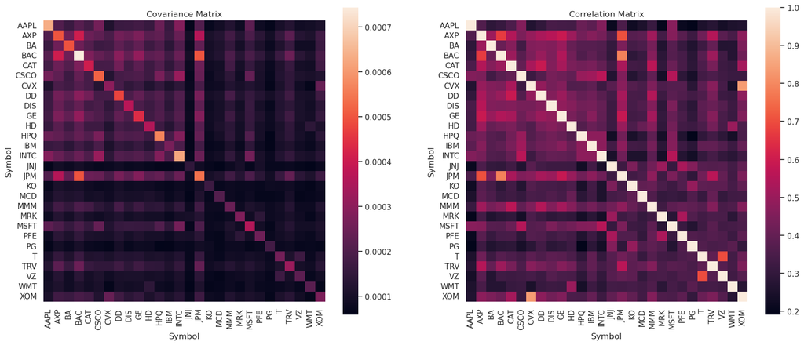

```python
import matplotlib.pyplot as plt
import seaborn as sns
fig, ax = plt.subplots(1, 2, figsize=(20, 8))
sns.heatmap(logret.cov(),  square=True, ax=ax[0]).set_title('Covariance Matrix')
sns.heatmap(logret.corr(), square=True, ax=ax[1]).set_title('Correlation Matrix');
# fig.show();
```

- Reordering variables group similar stocks together

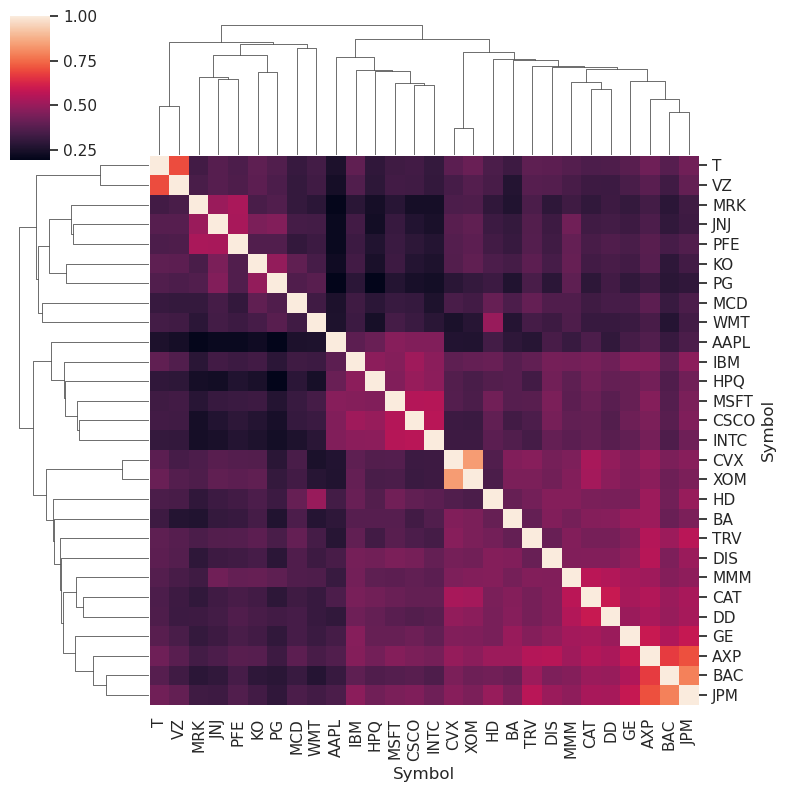

```python
clmap = sns.clustermap(logret.corr(), square=True, figsize=(8, 8));
ordering = clmap.dendrogram_col.reordered_ind # save the hierarchical clustering generated variable ordering
```

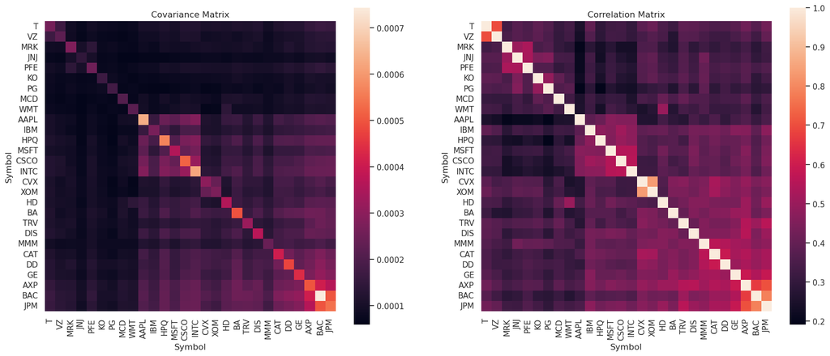

```python
fig, ax = plt.subplots(1, 2, figsize=(20, 8))
sns.heatmap(logret.cov().iloc[ordering, ordering],  square=True, ax=ax[0]).set_title('Covariance Matrix')
sns.heatmap(logret.corr().iloc[ordering, ordering], square=True, ax=ax[1]).set_title('Correlation Matrix');
# fig.show()
```

## Calculate Portfolio Allocation

### Minimum Variance Portfolio

- $\Sigma$ matrix is all that is specified
- $\Sigma$ characterizes the market
- Minimize variance of portfolio $R_p$

```python
s, _ = cov_sample.shape # calculated from data

w = cvx.Variable(s) # variables
risk = cvx.quad_form(w, cov_sample.values)  # objective function
prob = cvx.Problem(cvx.Minimize(risk), # optimization problem
               [cvx.sum(w) == 1])      # fully invested portfolio constraint
prob.solve()
```

```
8.182720882145511e-05
```

```python
w.value
```

```
array([ 0.01652722, -0.06677811, -0.00556869, -0.01420911,  0.00303467,
       -0.01916917,  0.03920442, -0.03985089,  0.01652121, -0.00538882,
       -0.02358231,  0.01211534,  0.09040282, -0.01447738,  0.2142491 ,
       -0.02886968,  0.1425609 ,  0.14683368,  0.06653689,  0.01455767,
        0.02968867,  0.02761711,  0.12084072,  0.00462494,  0.01039099,
        0.09993229,  0.13561062,  0.0266449 ])
```

- Positive weights indicate long positions
- Negative weights indicate short positions)
- Must sum to 1 (constraint)
- Other portfolio optimization variations:  
  http://nbviewer.jupyter.org/github/cvxgrp/cvx_short_course/blob/master/applications/portfolio_optimization.ipynb
- `cvxpy` package makes it easy to solve many types of problems easily

### MVP with target return

- Portfolio allocation problem with target expected return constraint:

$$ \min_{x\in\mathbb{R}^s}\ \ x^\intercal \Sigma x\\ \text{subject to }\mu^\intercal x\geq \mu^* \text{, and } \mathbf{1}^\intercal x = 1,$$

- Expected returns, $\mu$, is estimated from data (also $\Sigma$)
- Investor specifies target return $\mu^*$

```python
s,_ = cov_sample.shape

w = cvx.Variable(s)
risk = cvx.quad_form(w, cov_sample.values)
prob = cvx.Problem(cvx.Minimize(risk),
               [
                   cvx.sum(w) == 1,
                   mu.values@w >= 0.001,
                   # w >= 0
               ])
prob.solve()
```

```
0.00025582983343653144
```

```python
w.value
```

```
array([ 0.37727003,  0.0103586 ,  0.00531868, -0.19475594,  0.38319326,
       -0.1993208 ,  0.15270708, -0.22931477, -0.04446237, -0.22544009,
       -0.0039972 , -0.1268713 ,  0.07198615, -0.20353497,  0.43703468,
        0.20627437,  0.00312622,  0.32205393,  0.14227969, -0.07175241,
        0.18423752, -0.21650405,  0.10500898,  0.0260248 ,  0.16675933,
       -0.11354043,  0.12224684, -0.08638584])
```

- Higher target return achieved with more short positions
- Constraint: $\mu^\intercal w=0.001$
- Constraint: $\mathbf{1}^\intercal w=1$.

```python
w.value.sum()
```

```
0.9999999999999997
```

```python
np.dot(mu.values,w.value)
```

```
0.0010000000000000002
```

## Backtesting: portfolio returns

- Investing 1 dollar in a stock with 3% return over one time period makes me 3 cents:
  $$\$1 \cdot (1 + 0.03) = 1.03$$
- Investing a portfolio of worth $A_0$ dollars returns, $$ A = A_0 (1+r_t^T w_t), $$ where elements of $r_t$ are returns at time $t$ and $w$ is portfolio allocation
- Take allocation `w.value` and compute portfolio returns using historical returns: `logret`.

```python
earned = np.dot(logret.bfill().values, w.value)
```

- Compute portfolio growth

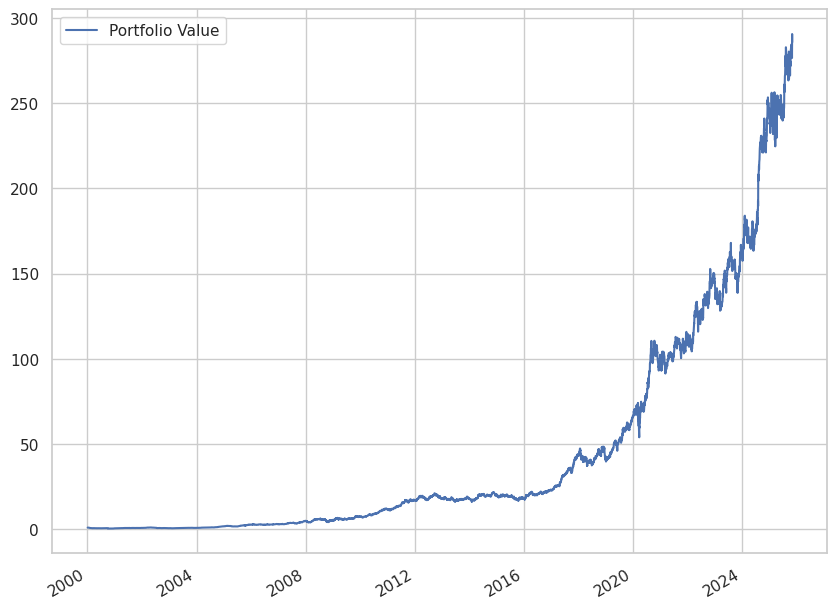

```python
earnedcp = (1+earned[1:]).cumprod()
ecp = pd.DataFrame(data=earnedcp.T, index=logret.index.values[1:], columns=['Portfolio Value'])
ecp.plot(figsize=(10, 8));
```

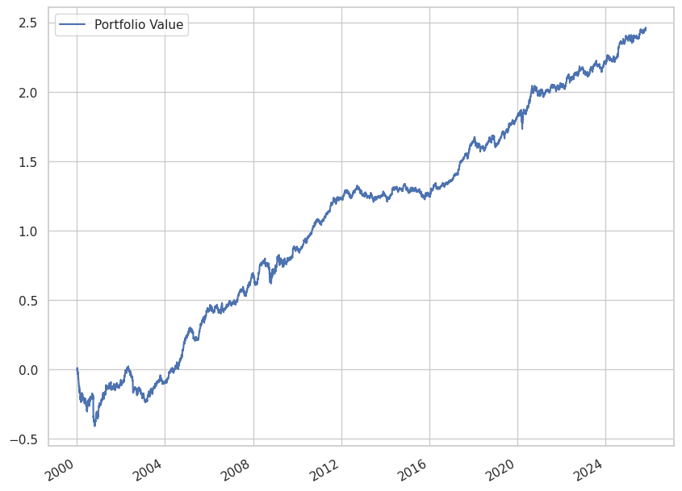

```python
np.log10(ecp).plot(figsize=(10, 8));
```

```python
ecp
```

|  | Portfolio Value |
| --- | --- |
| 2000-01-04 | 0.981337 |
| 2000-01-05 | 0.984165 |
| 2000-01-06 | 0.988135 |
| 2000-01-07 | 1.028528 |
| 2000-01-10 | 0.974107 |
| ... | ... |
| 2025-10-27 | 283.112617 |
| 2025-10-28 | 276.528236 |
| 2025-10-29 | 286.172518 |
| 2025-10-30 | 290.575876 |
| 2025-10-31 | 285.749925 |

6497 rows × 1 columns

- 1 dollar invested in 2000 would be 285 dollars today?
- Unrealistic! Why?
- Having knowledge of 20 years worth of data is cheating!

### Summarize results

```python
retinfo = logret.mean(axis=0).agg(['min', 'mean', 'max'])
stdinfo = logret.std(axis=0).agg(['min', 'mean', 'max'])

print('portfolio average returns:', earned.mean())
print('          average stddev :', earned.std())
print('')
print("component stocks average: minimum: %f\n                          average: %f\n                          maximum: %f" % tuple(retinfo))
print("component stocks stddev : minimum: %f\n                          average: %f\n                          maximum: %f" % tuple(stdinfo))
```

```
portfolio average returns: 0.0009969739339166317
          average stddev : 0.015994079712789433

component stocks average: minimum: 0.000074
                          average: 0.000295
                          maximum: 0.000889
component stocks stddev : minimum: 0.012085
                          average: 0.018796
                          maximum: 0.027256
```

Annual return would be:

```python
(1+earned.mean())**365 - 1
```

```
0.43866299874773973
```

Again, unrealistic

## Visualization of Relationships

- Correlations are stricly pairwise quantities (what about other stocks?)
- Inverse covariance

```python
from sklearn import preprocessing
scaler = preprocessing.StandardScaler()
scaled_df = scaler.fit_transform(logret.dropna().values)
scaled_df = pd.DataFrame(scaled_df, columns=logret.columns, index=logret.index[1:])
```

### Correlation Matrix: Year 2020

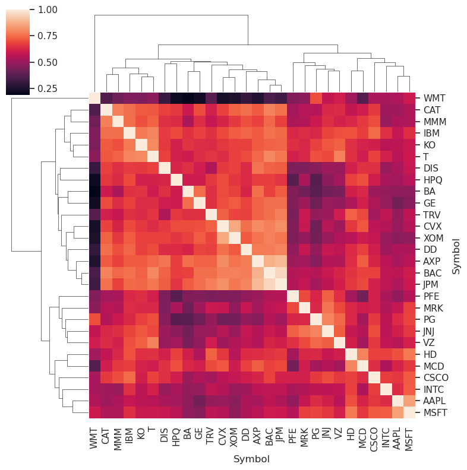

```python
clmap = sns.clustermap(scaled_df.loc['2020':'2020'].corr(), square=True, figsize=(8, 8));
ordering = clmap.dendrogram_col.reordered_ind # save the hierarchical clustering generated variable ordering
```

### Correlation Matrix: 2019 vs. 2020

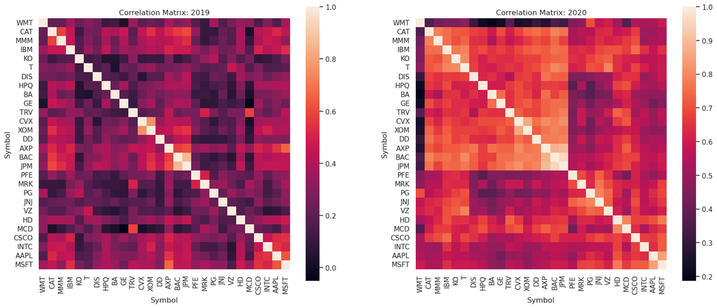

```python
fig, ax = plt.subplots(1, 2, figsize=(20, 8))

sns.heatmap(scaled_df.loc['2019':'2019'].corr().iloc[ordering, ordering],  square=True, ax=ax[0]).set_title('Correlation Matrix: 2019')
sns.heatmap(scaled_df.loc['2020':'2020'].corr().iloc[ordering, ordering],  square=True, ax=ax[1]).set_title('Correlation Matrix: 2020');
# fig.show()
```

## Reality check

Obviously, this cannot be realistic. What aspects were unrealistic?

1. We didn't take time into consideration: e.g. estimation of $\Sigma$ and selecting `w`.
2. We are investing with knowledge of the future returns!
3. We did not take into account transaction costs (we will have to)
4. We did not take into account shorting requires borrowing of money
5. Is investing in stocks better than leaving our money in a savings account? What is the interest rate?

Sharpe ratio tries to quantify the added benefit, i.e., excess returns, of investing in the volatile market by accounting for the volatility: $$\text{Sharpe ratio}=\frac{E\left[R_{p}-R_{f}\right]}{\sigma_{p}}$$ where $R_f$ is the risk-free rate.

## Backtesting

```python
# Rolling backtest with 300-day lookback and 50-day rebalance horizon

def estimate_moments(returns_df, cov_fn=None):
  """
  Estimate mean vector and covariance matrix from a returns window.
  - returns_df: DataFrame of daily returns (rows: dates, cols: assets)
  - cov_fn: optional function taking returns_df and returning a covariance matrix
  """
  window = returns_df.dropna()
  mu_hat = window.mean()
  if cov_fn is None:
    cov_hat = window.cov()
  else:
    cov_hat = cov_fn(window)
    # Convert to DataFrame with consistent indexing if needed
    if not isinstance(cov_hat, pd.DataFrame):
      cov_hat = pd.DataFrame(cov_hat, index=window.columns, columns=window.columns)
  return mu_hat, cov_hat


def compute_min_var_weights(mu_vec, cov_mat, target_return=None, long_only=False, ridge=1e-6, solver_opts=None):
  """
  Solve for portfolio weights minimizing variance:
    min w' Σ w
    s.t. 1' w = 1
       μ' w >= target_return (optional)
       w >= 0 (if long_only)
  - mu_vec: pd.Series indexed by asset
  - cov_mat: pd.DataFrame with same index/columns
  - ridge: small diagonal loading for numerical stability
  """
  cols = mu_vec.index
  Sigma = cov_mat.copy()
  # numerical stabilizer
  Sigma.values[range(Sigma.shape[0]), range(Sigma.shape[0])] += ridge

  n = len(cols)
  w_var = cvx.Variable(n)
  constraints = [cvx.sum(w_var) == 1]
  if long_only:
    constraints.append(w_var >= 0)
  if target_return is not None:
    constraints.append(mu_vec.values @ w_var >= float(target_return))

  objective = cvx.Minimize(cvx.quad_form(w_var, Sigma.values))
  prob_local = cvx.Problem(objective, constraints)
  prob_local.solve(**(solver_opts or {}))
  w_val = w_var.value
  if w_val is None or np.any(np.isnan(w_val)):
    raise RuntimeError("Solver returned invalid weights")
  weights = pd.Series(w_val, index=cols, name='weight')
  return weights


def compute_portfolio_returns(returns_df, weights):
  """
  Compute daily portfolio returns given returns matrix and weights.
  - returns_df: DataFrame (dates x assets)
  - weights: pd.Series indexed by assets
  """
  # align columns
  common = [c for c in returns_df.columns if c in weights.index]
  if len(common) == 0:
    return pd.Series([], dtype=float)
  w = weights.loc[common]
  R = returns_df[common]
  # dot product per day
  return R.dot(w)


def rolling_backtest(returns,
           lookback=300,
           horizon=50,
           rebalance=50,
           cov_fn=None,
           target_return=None,
           long_only=True,
           ridge=1e-6,
           solver_opts=None):
  """
  Rolling backtest:
  - Use past `lookback` days to estimate mu, Sigma
  - Invest for next `horizon` days with fixed weights
  - Rebalance every `rebalance` days
  Returns:
    dict with:
    'returns': pd.Series of daily portfolio returns over backtest
    'weights': pd.DataFrame of weights per rebalance date (rows=dates, cols=assets)
  """
  dates = returns.index
  n = len(dates)
  out_returns_parts = []
  weights_records = []

  start = lookback
  while start < n:
    end_invest = min(start + horizon, n)

    window = returns.iloc[start - lookback:start]
    mu_hat, cov_hat = estimate_moments(window, cov_fn=cov_fn)
    w_hat = compute_min_var_weights(mu_hat, cov_hat,
                    target_return=target_return,
                    long_only=long_only,
                    ridge=ridge,
                    solver_opts=solver_opts)

    period_rets = returns.iloc[start:end_invest]
    port_rets = compute_portfolio_returns(period_rets, w_hat)
    out_returns_parts.append(port_rets)

    # store weights at the rebalance date
    w_row = w_hat.reindex(returns.columns).fillna(0.0)
    w_row.name = dates[start]
    weights_records.append(w_row)

    # advance to next rebalance
    start += rebalance

  out_returns = pd.concat(out_returns_parts).sort_index()
  weights_df = pd.DataFrame(weights_records)
  return {'returns': out_returns, 'weights': weights_df}
```

```python
# Run the requested backtest on the existing `logret` DataFrame
bt = rolling_backtest(
  logret,
  lookback=300,
  horizon=50,
  rebalance=50,
  cov_fn=None,          # default: sample covariance
  target_return=None,   # pure minimum-variance
  long_only=False,       # set False to allow shorting
  ridge=1e-6,
)

bt_returns = bt['returns']
bt_weights = bt['weights']

# Example outputs: cumulative growth from log returns
bt_wealth = np.exp(bt_returns.cumsum())
bt_results = {
  'final_wealth': float(bt_wealth.iloc[-1]) if len(bt_wealth) else np.nan,
  'mean_daily_return': float(bt_returns.mean()) if len(bt_returns) else np.nan,
  'std_daily_return': float(bt_returns.std()) if len(bt_returns) else np.nan,
}

bt_results
```

```
{'final_wealth': 5.631200904168396,
 'mean_daily_return': 0.0002788516818128177,
 'std_daily_return': 0.009221033517696169}
```

```python
# perform backtest using ledoit-wolf shrinkage covariance estimator
from sklearn.covariance import LedoitWolf
def ledoit_wolf_cov(returns_df):
  lw = LedoitWolf().fit(returns_df.dropna().values)
  cov_est = lw.covariance_
  return pd.DataFrame(cov_est, index=returns_df.columns, columns=returns_df.columns)
bt_lw = rolling_backtest(
  logret,
  lookback=300,
  horizon=50,
  rebalance=50,
  cov_fn=ledoit_wolf_cov,
  target_return=None,
  long_only=False,
  ridge=1e-6,
)
bt_lw_returns = bt_lw['returns']
bt_lw_wealth = np.exp(bt_lw_returns.cumsum())
bt_lw_results = {
  'final_wealth': float(bt_lw_wealth.iloc[-1]) if len(bt_lw_wealth) else np.nan,
  'mean_daily_return': float(bt_lw_returns.mean()) if len(bt_lw_returns) else np.nan,
  'std_daily_return': float(bt_lw_returns.std()) if len(bt_lw_returns) else np.nan,
}

bt_lw_results
```

```
{'final_wealth': 5.843559184966783,
 'mean_daily_return': 0.000284824146608879,
 'std_daily_return': 0.009095051514796566}
```

```python
# perform backtest using graphical lasso covariance estimator
from sklearn.covariance import GraphicalLasso
def graphical_lasso_cov(returns_df, alpha=0.01):
  gl = GraphicalLasso(alpha=alpha).fit(returns_df.dropna().values)
  cov_est = gl.covariance_
  return pd.DataFrame(cov_est, index=returns_df.columns, columns=returns_df.columns)

bt_gl = rolling_backtest(
  logret,
  lookback=300,
  horizon=50,
  rebalance=50,
  cov_fn=graphical_lasso_cov,
  target_return=None,
  long_only=False,
  ridge=1e-6,
)
bt_gl_returns = bt_gl['returns']
bt_gl_wealth = np.exp(bt_gl_returns.cumsum())
bt_gl_results = {
  'final_wealth': float(bt_gl_wealth.iloc[-1]) if len(bt_gl_wealth) else np.nan,
  'mean_daily_return': float(bt_gl_returns.mean()) if len(bt_gl_returns) else np.nan,
  'std_daily_return': float(bt_gl_returns.std()) if len(bt_gl_returns) else np.nan,
}

bt_gl_results
```

```
{'final_wealth': 7.13234951776576,
 'mean_daily_return': 0.0003169797847334469,
 'std_daily_return': 0.010463294745776675}
```

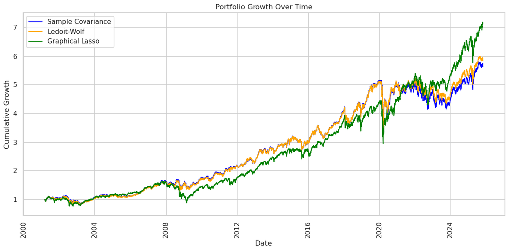

```python
# Plot the growth of the three portfolios
plt.figure(figsize=(12, 6))
plt.plot(bt_wealth.index, bt_wealth.values, label='Sample Covariance', color='blue')
plt.plot(bt_lw_wealth.index, bt_lw_wealth.values, label='Ledoit-Wolf', color='orange')
plt.plot(bt_gl_wealth.index, bt_gl_wealth.values, label='Graphical Lasso', color='green')
plt.title('Portfolio Growth Over Time')
plt.xlabel('Date')
plt.ylabel('Cumulative Growth')
plt.legend()
plt.xticks(rotation=90)
plt.tight_layout()
plt.show()
```

```python
store['logret'] = logret
store.close()
```